[figure not shown]

# Optimisez de la gestion des données de la boutique

BottleNeck gère actuellement ses stocks via un EPR qui n'est pas lié au site de vente en ligne. La gestion de ceux-ci est complexe et les analyses des ventes sur le Net manque de visibilité. Une table relationnelle entre les données EPR et Web a été établie avec la liste exhaustive des produits.

Nous avons donc deux bases de données, l'une pour l'EPR et l'autre pour l'e-shop et une table relationnelle. Comment simplifier la gestion des stocks et améliorer la visibilité des ventes ?

Les étapes :

- Rapprocher les 2 bases de données
- Mise en évidence du chiffre d'affaire
- Analyse des données de prix

# Sommaire

## Mise en place de l'environnement

### Importation des librairies

```python
import pandas as pd
import numpy as np
import os, sys
from IPython.display import display
import matplotlib.pyplot as plt
import seaborn as sns
plt.style.use('seaborn')

import warnings
warnings.filterwarnings("ignore")
```

### Constantes et configuration

```python
# path to data folder
DATA_PATH = os.path.realpath('') + '/data/'

# Pandas settings
pd.set_option("display.max_columns", 50)
pd.set_option("display.max_rows", 100)
pd.options.display.float_format = '{:,.2f}'.format
```

### Fonctions

```python
def import_xls_to_dataframe(filename):
    """
    Convert xls file to pandas dataframe

    args
        filename: name of file with extension
    returns
        pandas dataframe
    """
    try:
        return pd.read_excel(DATA_PATH + filename, engine='openpyxl')
    except Exception as e:
        print(">>> Le fichier {} est introuvable.".format(filename))
        sys.exit(e)

def is_primary_key(dataframe, column):
    """
    Check if values of column are primary keys

    args:
        dataframe: pandas dataframe
        column: column name to check
    returns:
        boolean
    """
    if column not in dataframe.columns:
        raise ValueError("'{}' n'est pas une colonne de la dataframe".format(column))

    return len(dataframe.drop_duplicates(subset=column)) == len(dataframe)
```

## Importation et nettoyage des données

Il y a 3 jeux de données : *EPR : inventaire des produits* Web : catalogue boutique en ligne * Liaison : table relationnelle EPR <-> Web

### Données ERP

La table ERP représente le listing de 825 produits avec leurs prix et leurs disponibilités.

#### Importation des données

```python
df_erp = import_xls_to_dataframe('erp.xlsx')
df_erp.head(5)
```

|  | product_id | onsale_web | price | stock_quantity | stock_status |
| --- | --- | --- | --- | --- | --- |
| 0 | 3847 | 1 | 24.20 | 0 | outofstock |
| 1 | 3849 | 1 | 34.30 | 0 | outofstock |
| 2 | 3850 | 1 | 20.80 | 0 | outofstock |
| 3 | 4032 | 1 | 14.10 | 0 | outofstock |
| 4 | 4039 | 1 | 46.00 | 0 | outofstock |

- product_id : référence du produit
- onsale_web : en vente sur la boutique en ligne
- price : prix du produit
- stock_quantity : quantité en stock
- stock_status : état du stock

#### Exploration

```python
df_erp.info()
```

```
<class 'pandas.core.frame.DataFrame'>
RangeIndex: 825 entries, 0 to 824
Data columns (total 5 columns):
 #   Column          Non-Null Count  Dtype
---  ------          --------------  -----
 0   product_id      825 non-null    int64
 1   onsale_web      825 non-null    int64
 2   price           825 non-null    float64
 3   stock_quantity  825 non-null    int64
 4   stock_status    825 non-null    object
dtypes: float64(1), int64(3), object(1)
memory usage: 32.4+ KB
```

> Les nombres de valeurs non null des différentes colonnes correspondent aux nombre de lignes du dataset.  
> Il n'y a donc pas de valeurs null dans les données.  
> Les types de données sont corrects.  
> 825 produits référencés dans le catalogue.

```python
df_erp.describe(include='all')
```

|  | product_id | onsale_web | price | stock_quantity | stock_status |
| --- | --- | --- | --- | --- | --- |
| count | 825.00 | 825.00 | 825.00 | 825.00 | 825 |
| unique | NaN | NaN | NaN | NaN | 2 |
| top | NaN | NaN | NaN | NaN | instock |
| freq | NaN | NaN | NaN | NaN | 638 |
| mean | 5,162.60 | 0.87 | 32.42 | 26.50 | NaN |
| std | 902.64 | 0.34 | 26.80 | 45.89 | NaN |
| min | 3,847.00 | 0.00 | 5.20 | 0.00 | NaN |
| 25% | 4,348.00 | 1.00 | 14.60 | 1.00 | NaN |
| 50% | 4,907.00 | 1.00 | 24.40 | 11.00 | NaN |
| 75% | 5,805.00 | 1.00 | 42.00 | 34.00 | NaN |
| max | 7,338.00 | 1.00 | 225.00 | 578.00 | NaN |

```python
list(df_erp['onsale_web'].unique())
```

```
[1, 0]
```

> Variables "price" et "stock_quantity" : pas de quantités négatives ou non renseignées.  
> Variables "onsale_web" et "stock_status" : variables qualitatives et ne possèdent que 2 modalités chacune.

#### Vérification des clés primaires

```python
is_primary_key(df_erp, 'product_id')
```

```
True
```

> La colonne 'product_id' est bien une clé primaire qui référence les différents produits. Elle peut être utilisée pour une jointure de données.

### Données WEB

La table Web contient les informations des produits commercialisés en ligne.

#### Importation des données

```python
df_web = import_xls_to_dataframe('web.xlsx')
df_web.head()
```

|  | sku | virtual | downloadable | rating_count | average_rating | total_sales | tax_status | tax_class | post_author | post_date | post_date_gmt | post_content | post_title | post_excerpt | post_status | comment_status | ping_status | post_password | post_name | post_modified | post_modified_gmt | post_content_filtered | post_parent | guid | menu_order | post_type | post_mime_type | comment_count |
| --- | --- | --- | --- | --- | --- | --- | --- | --- | --- | --- | --- | --- | --- | --- | --- | --- | --- | --- | --- | --- | --- | --- | --- | --- | --- | --- | --- | --- |
| 0 | bon-cadeau-25-euros | 0 | 0 | 0 | 0.00 | 10.00 | taxable | NaN | 1.00 | 2018-06-01 13:53:46 | 2018-06-01 11:53:46 | NaN | Bon cadeau de 25€ | <span style="color: #a85253;"><strong>Parlons ... | publish | closed | closed | NaN | bon-cadeau-de-25-euros | 2018-06-01 14:13:57 | 2018-06-01 12:13:57 | NaN | 0.00 | https://www.bottle-neck.fr/?post_type=product&... | 0.00 | product | NaN | 0.00 |
| 1 | 15298 | 0 | 0 | 0 | 0.00 | 6.00 | taxable | NaN | 2.00 | 2018-02-08 12:58:52 | 2018-02-08 11:58:52 | NaN | Pierre Jean Villa Saint-Joseph Préface 2018 | Il exhale un nez subtil, racé avec du poivre f... | publish | closed | closed | NaN | pierre-jean-villa-saint-joseph-preface-2018 | 2019-12-30 09:30:29 | 2019-12-30 08:30:29 | NaN | 0.00 | https://www.bottle-neck.fr/?post_type=product&... | 0.00 | product | NaN | 0.00 |
| 2 | 15296 | 0 | 0 | 0 | 0.00 | 0.00 | taxable | NaN | 2.00 | 2018-02-08 13:49:41 | 2018-02-08 12:49:41 | NaN | Pierre Jean Villa Saint-Joseph Rouge Tildé 2017 | Les vieilles vignes lui apportent une rare pro... | publish | closed | closed | NaN | pierre-jean-villa-saint-joseph-tilde-2017 | 2019-12-21 09:00:17 | 2019-12-21 08:00:17 | NaN | 0.00 | https://www.bottle-neck.fr/?post_type=product&... | 0.00 | product | NaN | 0.00 |
| 3 | 15300 | 0 | 0 | 0 | 0.00 | 0.00 | taxable | NaN | 2.00 | 2018-02-08 14:08:36 | 2018-02-08 13:08:36 | NaN | Pierre Jean Villa Crozes-Hermitage Accroche Co... | Dentelle de fruit de jeunes syrah, aux tanins ... | publish | closed | closed | NaN | pierre-jean-villa-croze-hermitage-accroche-coe... | 2020-06-26 18:15:03 | 2020-06-26 16:15:03 | NaN | 0.00 | https://www.bottle-neck.fr/?post_type=product&... | 0.00 | product | NaN | 0.00 |
| 4 | 19814 | 0 | 0 | 0 | 0.00 | 3.00 | taxable | NaN | 2.00 | 2018-02-09 14:01:05 | 2018-02-09 13:01:05 | NaN | Pierre Jean Villa IGP Collines Rhodaniennes Ga... | Gamine représente tout le fruité et la gourman... | publish | closed | closed | NaN | pierre-jean-villa-igp-gamine-2018 | 2020-01-04 16:36:01 | 2020-01-04 15:36:01 | NaN | 0.00 | https://www.bottle-neck.fr/?post_type=product&... | 0.00 | product | NaN | 0.00 |

#### Nettoyage des données

```python
# keep interesting columns
df_web = df_web[['sku', 'total_sales', 'post_title', 'post_type']]
df_web
```

|  | sku | total_sales | post_title | post_type |
| --- | --- | --- | --- | --- |
| 0 | bon-cadeau-25-euros | 10.00 | Bon cadeau de 25€ | product |
| 1 | 15298 | 6.00 | Pierre Jean Villa Saint-Joseph Préface 2018 | product |
| 2 | 15296 | 0.00 | Pierre Jean Villa Saint-Joseph Rouge Tildé 2017 | product |
| 3 | 15300 | 0.00 | Pierre Jean Villa Crozes-Hermitage Accroche Co... | product |
| 4 | 19814 | 3.00 | Pierre Jean Villa IGP Collines Rhodaniennes Ga... | product |
| ... | ... | ... | ... | ... |
| 1508 | 16135 | 5.00 | Mouthes Le Bihan Côtes de Duras L'Aimé Chai 2015 | attachment |
| 1509 | 15891 | 0.00 | Camin Larredya Jurançon Sec La Virada 2018 | attachment |
| 1510 | 15887 | 0.00 | Domaine Jamet Côte Rôtie Fructus Voluptas 2018 | attachment |
| 1511 | 13127-1 | 0.00 | Clos du Mont-Olivet Châteauneuf-du-Pape 2007 | attachment |
| 1512 | 16230 | 0.00 | Domaine Saint-Nicolas Vin de France Blanc Les ... | attachment |

1513 rows × 4 columns

- sku : référence du produit dans la boutique en ligne
- total_sales : nombre total de ventes
- post_title : intitulé du produit
- post_type : type de publication

```python
df_web.info()
```

```
<class 'pandas.core.frame.DataFrame'>
RangeIndex: 1513 entries, 0 to 1512
Data columns (total 4 columns):
 #   Column       Non-Null Count  Dtype
---  ------       --------------  -----
 0   sku          1428 non-null   object
 1   total_sales  1430 non-null   float64
 2   post_title   1430 non-null   object
 3   post_type    1430 non-null   object
dtypes: float64(1), object(3)
memory usage: 47.4+ KB
```

> La colonne 'sku' correspond aux références des produits dans la base de la boutique en ligne.  
> Les types de données dont corrects.  
> Il y a des références qui sont null.

**Filtre des sku null :**

```python
# delete null rows
df_web_id_nan = df_web[df_web['sku'].isnull()]
df_web_id_nan.info()
```

```
<class 'pandas.core.frame.DataFrame'>
Int64Index: 85 entries, 178 to 796
Data columns (total 4 columns):
 #   Column       Non-Null Count  Dtype
---  ------       --------------  -----
 0   sku          0 non-null      object
 1   total_sales  2 non-null      float64
 2   post_title   2 non-null      object
 3   post_type    2 non-null      object
dtypes: float64(1), object(3)
memory usage: 3.3+ KB
```

```python
df_post_notnull = df_web_id_nan[df_web_id_nan['post_type'].notnull()]
df_post_notnull
```

|  | sku | total_sales | post_title | post_type |
| --- | --- | --- | --- | --- |
| 470 | NaN | 0.00 | Pierre Jean Villa Côte Rôtie Fongeant 2017 | product |
| 471 | NaN | 0.00 | Pierre Jean Villa Condrieu Jardin Suspendu 2018 | product |

> Les sku null n'apportent pas d'informations complémentaires, on peut les supprimer.  
> Les références null, au nombre de 85, peuvent être supprimées.

**Suppresion des lignes null :**

```python
df_web = df_web[df_web['sku'].notna()]
df_web.info()
```

```
<class 'pandas.core.frame.DataFrame'>
Int64Index: 1428 entries, 0 to 1512
Data columns (total 4 columns):
 #   Column       Non-Null Count  Dtype
---  ------       --------------  -----
 0   sku          1428 non-null   object
 1   total_sales  1428 non-null   float64
 2   post_title   1428 non-null   object
 3   post_type    1428 non-null   object
dtypes: float64(1), object(3)
memory usage: 55.8+ KB
```

> Dans les données ERP, il y a 825 produits référencés.  
> On retrouve ici 1428 posts dans la boutique en ligne. Il y a donc des doublons.

**Traitement des doublons :**

```python
df_web[df_web['sku'] == 38]
```

|  | sku | total_sales | post_title | post_type |
| --- | --- | --- | --- | --- |
| 339 | 38 | 38.00 | Emile Boeckel Crémant Brut Blanc de Blancs | product |
| 1123 | 38 | 38.00 | Emile Boeckel Crémant Brut Blanc de Blancs | attachment |

> Les doublons correspondent aux pièces jointes aux posts.

```python
# filter product only
df_web = df_web[df_web['post_type'] == 'product']
```

```python
df_web.info()
```

```
<class 'pandas.core.frame.DataFrame'>
Int64Index: 714 entries, 0 to 798
Data columns (total 4 columns):
 #   Column       Non-Null Count  Dtype
---  ------       --------------  -----
 0   sku          714 non-null    object
 1   total_sales  714 non-null    float64
 2   post_title   714 non-null    object
 3   post_type    714 non-null    object
dtypes: float64(1), object(3)
memory usage: 27.9+ KB
```

**Vérification des valeurs numériques :**

```python
df_web.describe()
```

|  | total_sales |
| --- | --- |
| count | 714.00 |
| mean | 4.01 |
| std | 8.52 |
| min | 0.00 |
| 25% | 0.00 |
| 50% | 1.00 |
| 75% | 4.00 |
| max | 96.00 |

> Pas de quantitées vendues négatives et toutes les valeurs sont renseignées.

#### Vérification des clés primaires

```python
is_primary_key(df_web, 'sku')
```

```
True
```

> La colonne 'id_web' est bien une clé primaire qui référence les différents produits de la boutique.

### Données LIAISON

Les données liaison servent de lien entre les données ERP et WEB. Ces doivent être des clés primaires entre ces deux jeux de données.

#### Importation des données

```python
df_link = import_xls_to_dataframe("liaison.xlsx")
df_link.head(5)
```

|  | product_id | id_web |
| --- | --- | --- |
| 0 | 3847 | 15298 |
| 1 | 3849 | 15296 |
| 2 | 3850 | 15300 |
| 3 | 4032 | 19814 |
| 4 | 4039 | 19815 |

```python
# Rename columns
df_link.rename(columns={'id_web':'sku'}, inplace=True)
```

#### Vérification des clés primaires

```python
df_link.info()
```

```
<class 'pandas.core.frame.DataFrame'>
RangeIndex: 825 entries, 0 to 824
Data columns (total 2 columns):
 #   Column      Non-Null Count  Dtype
---  ------      --------------  -----
 0   product_id  825 non-null    int64
 1   sku         734 non-null    object
dtypes: int64(1), object(1)
memory usage: 13.0+ KB
```

##### product_id

```python
is_primary_key(df_link, 'product_id')
```

```
True
```

##### id_web

On créé un dataframe temporaire pour vérifier les références uniques des 'sku' du fichier liaison.

```python
df_link_temp = df_link[df_link['sku'].notna()]
is_primary_key(df_link_temp, 'sku')
```

```
True
```

> On retrouve des valeurs uniques dans les deux colonnes de liaisons (hors valeurs nulls).  
> Les valeurs nulls de la colonne 'id_web' représentent des produits qui ne sont pas référencés par la boutique.

## Liaison des données

### Relation données EPR

Pour vérifier les liaisons, on compare les références de la table link avec les colonnes des clés primaire de la table EPR.

```python
# get lists of id from epr and link table
list_epr_product_id = df_erp['product_id'].tolist()
list_link_product_id = df_link['product_id'].tolist()
```

```python
print(all(item in list_link_product_id for item in list_epr_product_id))
```

```
True
```

```python
print(all(item in list_epr_product_id for item in list_link_product_id))
```

```
True
```

> On retrouve les même 'product_id' dans le fichier "erp" et "liaison".

### Relation données Web

Pour vérifier les liaisons, on compare les références de la table link avec les colonnes des clés primaire de la table Web.

```python
# get lists of id from web and link table
list_web_sku = df_web['sku'].tolist()
list_link_sku = df_link['sku'].tolist()
```

```python
print(all(item in list_link_sku for item in list_web_sku))
```

```
True
```

> Tous les produits présents dans la boutique sont référencés dans la table de relation.

```python
print(all(item in list_web_sku for item in list_link_sku))
```

```
False
```

> Tous les produits référencés en sku dans la table link ne sont pas présents sur la boutique.

Liste des produits non publiés sur la boutique :

```python
new_list = list(set(list_link_sku).difference(list_web_sku))
print(new_list)
```

```
[nan, 13577, 14730, 15630, 14360, 15272, 14377, 15529, 14379, 15154, 14648, 12601, '14680-1', 14785, 13771, 15065, 14689, 15586, 15608, 15609, 14715]
```

> Il est intéressant de voir quels sont les produits en stock mais pas mis en vente sur la boutique en ligne.  
> Certains produits ne sont pas publiés sur la boutique en ligne.

### Relation liason des données

Pour analyser les données, on join les tables ERP et Web grâçe à la table link.

#### Jointure Web

On commence par joindre la table link et web.

```python
df_main = pd.merge(df_link, df_web, on="sku", how="outer")
df_main
```

|  | product_id | sku | total_sales | post_title | post_type |
| --- | --- | --- | --- | --- | --- |
| 0 | 3847 | 15298 | 6.00 | Pierre Jean Villa Saint-Joseph Préface 2018 | product |
| 1 | 3849 | 15296 | 0.00 | Pierre Jean Villa Saint-Joseph Rouge Tildé 2017 | product |
| 2 | 3850 | 15300 | 0.00 | Pierre Jean Villa Crozes-Hermitage Accroche Co... | product |
| 3 | 4032 | 19814 | 3.00 | Pierre Jean Villa IGP Collines Rhodaniennes Ga... | product |
| 4 | 4039 | 19815 | 0.00 | Pierre Jean Villa Côte Rôtie Carmina 2017 | product |
| ... | ... | ... | ... | ... | ... |
| 820 | 7023 | 15891 | 0.00 | Camin Larredya Jurançon Sec La Virada 2018 | product |
| 821 | 7025 | 15887 | 0.00 | Domaine Jamet Côte Rôtie Fructus Voluptas 2018 | product |
| 822 | 7247 | 13127-1 | 0.00 | Clos du Mont-Olivet Châteauneuf-du-Pape 2007 | product |
| 823 | 7329 | 14680-1 | NaN | NaN | NaN |
| 824 | 7338 | 16230 | 0.00 | Domaine Saint-Nicolas Vin de France Blanc Les ... | product |

825 rows × 5 columns

```python
df_main.info()
```

```
<class 'pandas.core.frame.DataFrame'>
Int64Index: 825 entries, 0 to 824
Data columns (total 5 columns):
 #   Column       Non-Null Count  Dtype
---  ------       --------------  -----
 0   product_id   825 non-null    int64
 1   sku          734 non-null    object
 2   total_sales  714 non-null    float64
 3   post_title   714 non-null    object
 4   post_type    714 non-null    object
dtypes: float64(1), int64(1), object(3)
memory usage: 38.7+ KB
```

> Le nombre de lignes reste à 825. Il n'y a pas de perte d'informations.

#### Jointure ERP

On joint ensuite la table obtenue avec la table ERP. La méthode "outer" permet de garder le maximum de données.

```python
df_main = pd.merge(df_erp, df_main, on="product_id", how="outer")
df_main.head()
```

|  | product_id | onsale_web | price | stock_quantity | stock_status | sku | total_sales | post_title | post_type |
| --- | --- | --- | --- | --- | --- | --- | --- | --- | --- |
| 0 | 3847 | 1 | 24.20 | 0 | outofstock | 15298 | 6.00 | Pierre Jean Villa Saint-Joseph Préface 2018 | product |
| 1 | 3849 | 1 | 34.30 | 0 | outofstock | 15296 | 0.00 | Pierre Jean Villa Saint-Joseph Rouge Tildé 2017 | product |
| 2 | 3850 | 1 | 20.80 | 0 | outofstock | 15300 | 0.00 | Pierre Jean Villa Crozes-Hermitage Accroche Co... | product |
| 3 | 4032 | 1 | 14.10 | 0 | outofstock | 19814 | 3.00 | Pierre Jean Villa IGP Collines Rhodaniennes Ga... | product |
| 4 | 4039 | 1 | 46.00 | 0 | outofstock | 19815 | 0.00 | Pierre Jean Villa Côte Rôtie Carmina 2017 | product |

```python
df_main.info()
```

```
<class 'pandas.core.frame.DataFrame'>
Int64Index: 825 entries, 0 to 824
Data columns (total 9 columns):
 #   Column          Non-Null Count  Dtype
---  ------          --------------  -----
 0   product_id      825 non-null    int64
 1   onsale_web      825 non-null    int64
 2   price           825 non-null    float64
 3   stock_quantity  825 non-null    int64
 4   stock_status    825 non-null    object
 5   sku             734 non-null    object
 6   total_sales     714 non-null    float64
 7   post_title      714 non-null    object
 8   post_type       714 non-null    object
dtypes: float64(2), int64(3), object(4)
memory usage: 64.5+ KB
```

> Le nombre de lignes reste à 825. Il n'y a pas de perte d'informations.

#### Réagencement

On sélectionne les données nécessaires aux analyses.

```python
df_main = df_main[[
    'product_id',
    'sku',
    'post_title',
    'stock_status',
    'onsale_web',
    'stock_quantity',
    'price',
    'total_sales'
]]
df_main
```

|  | product_id | sku | post_title | stock_status | onsale_web | stock_quantity | price | total_sales |
| --- | --- | --- | --- | --- | --- | --- | --- | --- |
| 0 | 3847 | 15298 | Pierre Jean Villa Saint-Joseph Préface 2018 | outofstock | 1 | 0 | 24.20 | 6.00 |
| 1 | 3849 | 15296 | Pierre Jean Villa Saint-Joseph Rouge Tildé 2017 | outofstock | 1 | 0 | 34.30 | 0.00 |
| 2 | 3850 | 15300 | Pierre Jean Villa Crozes-Hermitage Accroche Co... | outofstock | 1 | 0 | 20.80 | 0.00 |
| 3 | 4032 | 19814 | Pierre Jean Villa IGP Collines Rhodaniennes Ga... | outofstock | 1 | 0 | 14.10 | 3.00 |
| 4 | 4039 | 19815 | Pierre Jean Villa Côte Rôtie Carmina 2017 | outofstock | 1 | 0 | 46.00 | 0.00 |
| ... | ... | ... | ... | ... | ... | ... | ... | ... |
| 820 | 7203 | NaN | NaN | instock | 0 | 30 | 45.00 | NaN |
| 821 | 7204 | NaN | NaN | instock | 0 | 9 | 45.00 | NaN |
| 822 | 7247 | 13127-1 | Clos du Mont-Olivet Châteauneuf-du-Pape 2007 | instock | 1 | 23 | 54.80 | 0.00 |
| 823 | 7329 | 14680-1 | NaN | instock | 0 | 14 | 26.50 | NaN |
| 824 | 7338 | 16230 | Domaine Saint-Nicolas Vin de France Blanc Les ... | instock | 1 | 45 | 16.30 | 0.00 |

825 rows × 8 columns

## Reporting

### Chiffre d'affaire par produit

Pour le calcul des revenus, on multiple le prix de chacun des produits par leurs nombres de ventes respectifs.

```python
df_main['revenue'] = df_main['price'] * df_main['total_sales']
```

#### Produits les plus vendus

**Par revenue :**

```python
df_main.sort_values(['revenue'], ascending=False).head(10)
```

|  | product_id | sku | post_title | stock_status | onsale_web | stock_quantity | price | total_sales | revenue |
| --- | --- | --- | --- | --- | --- | --- | --- | --- | --- |
| 203 | 4334 | 7818 | Champagne Gosset Grand Blanc de Blancs | outofstock | 1 | 0 | 49.00 | 96.00 | 4,704.00 |
| 74 | 4144 | 1662 | Champagne Gosset Grand Rosé | instock | 1 | 11 | 49.00 | 87.00 | 4,263.00 |
| 227 | 4402 | 3510 | Cognac Frapin VIP XO | instock | 1 | 8 | 176.00 | 13.00 | 2,288.00 |
| 73 | 4142 | 11641 | Champagne Gosset Grand Millésime 2006 | instock | 1 | 8 | 53.00 | 30.00 | 1,590.00 |
| 72 | 4141 | 304 | Champagne Gosset Grande Réserve | instock | 1 | 1 | 39.00 | 40.00 | 1,560.00 |
| 210 | 4355 | 12589 | Champagne Egly-Ouriet Grand Cru Blanc de Noirs | instock | 1 | 2 | 126.50 | 11.00 | 1,391.50 |
| 208 | 4352 | 15940 | Champagne Egly-Ouriet Grand Cru Millésimé 2008 | outofstock | 1 | 0 | 225.00 | 5.00 | 1,125.00 |
| 82 | 4153 | 16237 | Elian Daros Côtes du Marmandais Clos Baquey 2015 | outofstock | 1 | 0 | 29.00 | 36.00 | 1,044.00 |
| 706 | 6206 | 16580 | Domaine Giudicelli Patrimonio Blanc 2019 | instock | 1 | 120 | 25.20 | 41.00 | 1,033.20 |
| 31 | 4068 | 16416 | Gilles Robin Crozes-Hermitage Rouge Papillon 2019 | instock | 1 | 157 | 16.60 | 62.00 | 1,029.20 |

> Les produits qui générent le plus de revenue sont des champagnes et un cognac.

**Par volume :**

```python
df_main.sort_values(['total_sales'], ascending=False).head(10)
```

|  | product_id | sku | post_title | stock_status | onsale_web | stock_quantity | price | total_sales | revenue |
| --- | --- | --- | --- | --- | --- | --- | --- | --- | --- |
| 203 | 4334 | 7818 | Champagne Gosset Grand Blanc de Blancs | outofstock | 1 | 0 | 49.00 | 96.00 | 4,704.00 |
| 74 | 4144 | 1662 | Champagne Gosset Grand Rosé | instock | 1 | 11 | 49.00 | 87.00 | 4,263.00 |
| 31 | 4068 | 16416 | Gilles Robin Crozes-Hermitage Rouge Papillon 2019 | instock | 1 | 157 | 16.60 | 62.00 | 1,029.20 |
| 123 | 4200 | 16295 | Moulin de Gassac IGP Pays d'Hérault Guilhem Ro... | instock | 1 | 190 | 5.80 | 46.00 | 266.80 |
| 100 | 4172 | 16210 | Maurel Pays d'Oc Chardonnay 2019 | instock | 1 | 167 | 5.70 | 43.00 | 245.10 |
| 112 | 4187 | 16189 | Le Pas de l'Escalette Languedoc Les Petits Pas... | instock | 1 | 90 | 13.30 | 42.00 | 558.60 |
| 706 | 6206 | 16580 | Domaine Giudicelli Patrimonio Blanc 2019 | instock | 1 | 120 | 25.20 | 41.00 | 1,033.20 |
| 72 | 4141 | 304 | Champagne Gosset Grande Réserve | instock | 1 | 1 | 39.00 | 40.00 | 1,560.00 |
| 678 | 6047 | 16264 | Château de La Liquière Faugères L'Ampoule 2019 | instock | 1 | 46 | 10.90 | 38.00 | 414.20 |
| 347 | 4729 | 38 | Emile Boeckel Crémant Brut Blanc de Blancs | instock | 1 | 151 | 8.60 | 38.00 | 326.80 |

> Les produits qui se vendent le plus sont des champagnes et des vins.

> Les stocks sont toutefois limités pour des produits qui se vendent bien. Il faudrait faire un restockage pour assurer les futures ventes.

#### Produits les moins vendus

**Par revenue :**

```python
df_less_sold = df_main[df_main['total_sales'] > 0]
df_less_sold.sort_values(['revenue']).head(10)
```

|  | product_id | sku | post_title | stock_status | onsale_web | stock_quantity | price | total_sales | revenue |
| --- | --- | --- | --- | --- | --- | --- | --- | --- | --- |
| 386 | 4858 | 16342 | Château Turcaud Bordeaux Rosé 2019 | instock | 1 | 257 | 6.50 | 1.00 | 6.50 |
| 479 | 5056 | 13531 | Domaine de Montgilet Anjou Rouge 2016 | instock | 1 | 9 | 7.50 | 1.00 | 7.50 |
| 99 | 4171 | 14332 | Le Hameau Des Ollieux Monsieur Pinot 2017 | instock | 1 | 65 | 7.80 | 1.00 | 7.80 |
| 155 | 4241 | 14725 | Parcé Frères IGP Côtes Catalanes Hommage à Fer... | instock | 1 | 7 | 8.90 | 1.00 | 8.90 |
| 158 | 4245 | 16097 | Parcé Frères IGP Pays d'Oc Zoé Viognier 2019 | instock | 1 | 141 | 8.90 | 1.00 | 8.90 |
| 312 | 4683 | 16239 | Château Plaisance Fronton Rosé 2019 | instock | 1 | 42 | 9.10 | 1.00 | 9.10 |
| 179 | 4272 | 13089 | Domaine Sérol Côte Roannaise Rosé Cabochard 2016 | instock | 1 | 25 | 9.20 | 1.00 | 9.20 |
| 681 | 6070 | 16133 | Borie La Vitarèle Pays d'Hérault Les Cigales 2019 | instock | 1 | 124 | 9.30 | 1.00 | 9.30 |
| 306 | 4677 | 15282 | Domaine Rotier Gaillac Rouge Les Gravels 2016 | instock | 1 | 161 | 9.50 | 1.00 | 9.50 |
| 169 | 4261 | 15662 | Chermette Domaine du Vissoux Beaujolais Griott... | instock | 1 | 89 | 9.90 | 1.00 | 9.90 |

**Par volume :**

```python
df_less_sold = df_main[df_main['total_sales'] == 0]
df_less_sold.sort_values(['stock_quantity'], ascending=False).head(10)
```

|  | product_id | sku | post_title | stock_status | onsale_web | stock_quantity | price | total_sales | revenue |
| --- | --- | --- | --- | --- | --- | --- | --- | --- | --- |
| 255 | 4609 | 15145 | François Bergeret Hautes Côtes de Beaune Rouge... | instock | 1 | 237 | 11.80 | 0.00 | 0.00 |
| 358 | 4749 | 15315 | Domaine de Montgilet Anjou Blanc 2016 | instock | 1 | 140 | 11.90 | 0.00 | 0.00 |
| 200 | 4304 | 15120 | Domaine de l'Idylle Savoie Cruet 2018 | instock | 1 | 133 | 8.10 | 0.00 | 0.00 |
| 605 | 5777 | 14338 | Maurel Pays d'Oc Cabernet-Sauvignon 2017 | instock | 1 | 132 | 5.70 | 0.00 | 0.00 |
| 611 | 5797 | 15688 | Château Saransot-Dupré Listrac-Médoc 2016 | instock | 1 | 123 | 17.20 | 0.00 | 0.00 |
| 256 | 4610 | 15801 | François Bergeret Hautes Côtes de Beaune Blanc... | instock | 1 | 114 | 13.10 | 0.00 | 0.00 |
| 705 | 6205 | 16565 | Domaine Giudicelli Vin de France Corail Rouge ... | instock | 1 | 109 | 20.20 | 0.00 | 0.00 |
| 104 | 4177 | 15583 | Domaine de l'Hortus Val de Montferrand La Berg... | instock | 1 | 109 | 13.50 | 0.00 | 0.00 |
| 122 | 4198 | 16322 | Moulin de Gassac IGP Pays d'Hérault Guilhem Ro... | instock | 1 | 105 | 5.80 | 0.00 | 0.00 |
| 362 | 4755 | 16132 | Domaine de Montgilet Vin de France Grolleau 2019 | instock | 1 | 97 | 7.40 | 0.00 | 0.00 |

> Parmis les moins vendus, les stocks sont importants. Il serait interressant de une opération marketing de destockage.

### Chiffre d'affaire globale

```python
df_main['revenue'].sum()
```

```
70568.6
```

> Le chiffre d'affaire globale est de 70 568.60 euros.

### Analyses complémentaires et recommandations

#### Produits en stock et indisponible à la vente

```python
df_no_sold = df_main[(df_main['stock_status'] == 'instock') & (df_main['onsale_web'] == 0)]
df_no_sold.sort_values(['stock_quantity'], ascending=False).head(10)
```

|  | product_id | sku | post_title | stock_status | onsale_web | stock_quantity | price | total_sales | revenue |
| --- | --- | --- | --- | --- | --- | --- | --- | --- | --- |
| 739 | 6594 | NaN | NaN | instock | 0 | 192 | 9.10 | NaN | NaN |
| 798 | 7087 | NaN | NaN | instock | 0 | 91 | 30.00 | NaN | NaN |
| 541 | 5560 | NaN | NaN | instock | 0 | 62 | 47.00 | NaN | NaN |
| 817 | 7196 | NaN | NaN | instock | 0 | 55 | 31.00 | NaN | NaN |
| 777 | 6903 | NaN | NaN | instock | 0 | 54 | 27.00 | NaN | NaN |
| 799 | 7088 | NaN | NaN | instock | 0 | 53 | 20.00 | NaN | NaN |
| 772 | 6898 | NaN | NaN | instock | 0 | 51 | 30.00 | NaN | NaN |
| 809 | 7164 | NaN | NaN | instock | 0 | 51 | 31.00 | NaN | NaN |
| 318 | 4692 | NaN | NaN | instock | 0 | 48 | 12.00 | NaN | NaN |
| 812 | 7170 | NaN | NaN | instock | 0 | 43 | 45.00 | NaN | NaN |

```python
df_no_sold.info()
```

```
<class 'pandas.core.frame.DataFrame'>
Int64Index: 64 entries, 234 to 823
Data columns (total 9 columns):
 #   Column          Non-Null Count  Dtype
---  ------          --------------  -----
 0   product_id      64 non-null     int64
 1   sku             2 non-null      object
 2   post_title      0 non-null      object
 3   stock_status    64 non-null     object
 4   onsale_web      64 non-null     int64
 5   stock_quantity  64 non-null     int64
 6   price           64 non-null     float64
 7   total_sales     0 non-null      float64
 8   revenue         0 non-null      float64
dtypes: float64(3), int64(3), object(3)
memory usage: 5.0+ KB
```

> Il y a 64 produits en stock qui ne sont pas disponibles à la vente.  
> Il faudrait les ajouter à la boutique pour pouvoir les vendre.

#### Produits épuisés et vendus

```python
df_off = df_main[(df_main['stock_status'] == 'outofstock')]
df_off.sort_values(['total_sales'], ascending=False).head(10)
```

|  | product_id | sku | post_title | stock_status | onsale_web | stock_quantity | price | total_sales | revenue |
| --- | --- | --- | --- | --- | --- | --- | --- | --- | --- |
| 203 | 4334 | 7818 | Champagne Gosset Grand Blanc de Blancs | outofstock | 1 | 0 | 49.00 | 96.00 | 4,704.00 |
| 403 | 4891 | 15807 | Jacqueson Rully Blanc 1er Cru La Pucelle 2018 | outofstock | 1 | 0 | 27.90 | 36.00 | 1,004.40 |
| 82 | 4153 | 16237 | Elian Daros Côtes du Marmandais Clos Baquey 2015 | outofstock | 1 | 0 | 29.00 | 36.00 | 1,044.00 |
| 395 | 4870 | 16149 | Triennes IGP Méditerranée Rosé 2019 | outofstock | 1 | 0 | 9.30 | 33.00 | 306.90 |
| 421 | 4918 | 15533 | Alain Graillot Crozes-Hermitage Rouge La Guira... | outofstock | 1 | 0 | 37.20 | 24.00 | 892.80 |
| 243 | 4596 | 15476 | Marc Colin Et Fils Chassagne-Montrachet Blanc ... | outofstock | 1 | 0 | 43.90 | 23.00 | 1,009.70 |
| 677 | 6042 | 16159 | Domaine La Croix Belle Côtes de Thongue Rosé L... | outofstock | 1 | 0 | 8.50 | 18.00 | 153.00 |
| 503 | 5439 | 15649 | La Préceptorie Maury Sec Rouge Copain Comme Co... | outofstock | 1 | 0 | 13.20 | 18.00 | 237.60 |
| 653 | 5922 | 15343 | Albert Mann Pinot Noir Clos de la Faille 2017 | outofstock | 1 | 0 | 48.50 | 17.00 | 824.50 |
| 483 | 5067 | 15346 | Albert Mann Pinot Noir Grand H 2017 | outofstock | 1 | 0 | 59.90 | 16.00 | 958.40 |

> Il y a des produits en rupture de stock où la demande est forte. Il faudrait faire un restockage pour poouvoir les remettre en vente au plus vite.

#### Intégrité des stocks

On vérifie l'indicateur stock_status.

```python
df_main[(df_main['stock_status'] == 'instock') & (df_main['stock_quantity'] == 0)]
```

|  | product_id | sku | post_title | stock_status | onsale_web | stock_quantity | price | total_sales | revenue |
| --- | --- | --- | --- | --- | --- | --- | --- | --- | --- |
| 443 | 4954 | bon-cadeau-25-euros | Bon cadeau de 25€ | instock | 1 | 0 | 25.00 | 10.00 | 250.00 |

```python
df_main[(df_main['stock_status'] == 'outofstock') & (df_main['stock_quantity'] > 0)]
```

|  | product_id | sku | post_title | stock_status | onsale_web | stock_quantity | price | total_sales | revenue |
| --- | --- | --- | --- | --- | --- | --- | --- | --- | --- |

## Analyse univariée des prix

On effectue une analyse univariée sur les prix afin de déterminer si il y a des erreurs de saisie dans les prix des produits et donc des valeurs aberrantes.

### Mesures statistiques

On récupère la pandas.series des prix :

```python
price_serie = df_main['price'].sort_values()
```

**Mesures de tendance centrale :**

```python
price_mean = price_serie.mean()
price_median = price_serie.median()
```

```python
print(f"""
Moyenne : {price_mean}
Médiane : {price_median}
""")
```

```
Moyenne : 32.41563636363637
Médiane : 24.4
```

> La distribution est asymétrique.

**Mesures de dispersion des données :**

```python
price_var = price_serie.var()
price_std = price_serie.std()
```

```python
print(f"""
Variance : {price_var}
Ecart-type : {price_std}
""")
```

```
Variance : 718.017534333628
Ecart-type : 26.79584919971054
```

> Les valeurs ne sont pas concentrés autour de la moyenne. La dispersion est importante.

**Mesures de forme :**

```python
# Skewness empirique
price_skew = price_serie.skew()

# Kurtosis empirique
price_kurt = price_serie.kurtosis()
```

```python
print(f"""
Skewness : {price_skew}
Kurtosis : {price_kurt}
""")
```

```
Skewness : 2.6227973685638717
Kurtosis : 10.615358266001198
```

> La distribution est étalée à droite. Les observations sont concentrées.

**Mesures de concentration :**

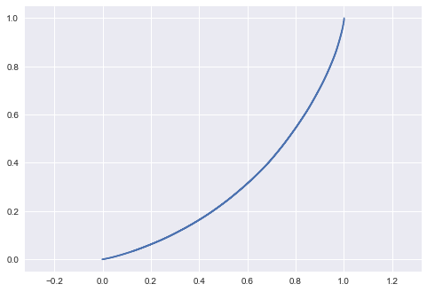

```python
# courbe de Lorenz
n = len(price_serie)
lorenz = np.cumsum(np.sort(price_serie)) / price_serie.sum()  # cumulate sum and normalization
lorenz = np.append([0],lorenz)

plt.axes().axis('equal')
xaxis = np.linspace(0-1/n,1+1/n,n+1)    # abscisses 0 to 1
plt.plot(xaxis,lorenz,drawstyle='steps-post')
plt.show()
```

> La répartition n'est pas égalitaire.

**Distribution empirique :**

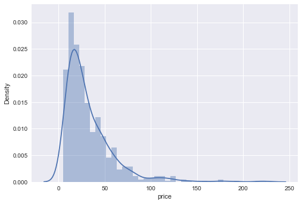

```python
sns.distplot(df_main.price)
```

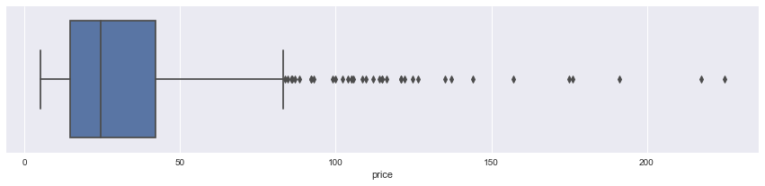

```python
plt.figure(figsize=(15,3))
sns.boxplot(df_main['price'])
plt.show()
```

Nous avons une distribution normale asymétrique. On retiendra dans notre cas la médiane comme indicateur de position centrale plutôt que la moyenne qui est sensible aux valeurs extrèmes.

### Recherche des outlier

Pour notre analyse univariée, une valeur aberrante est une “donnée observée” de prix qui semble anormal par rapoort aux valeurs de l'ensemble de l’échantillon. On remarque sur le diagramme de distribution, qu'il existe des valeurs trés grandes par rapport à l'ensemble des valeurs.  
Il est donc intéressant de cherchers si ces valeurs sont des outliers.

#### Méthode des Interquartiles

On va utiliser l'intervalle interquartile (IQR) qui est une mesure de la variabilité.  
Toutes les valeurs à l'extérieur de la limite inférieure et supérieure sont des outlier.

##### Calcule des limites

```python
# Calculate third quartile (Q3)
Q3 = np.quantile(price_serie, 0.75)

# Calculate first quartile (Q1)
Q1 = np.quantile(price_serie, 0.25)

# Calculate interquartile range (IQR)
IQR = Q3 - Q1

print(f"""
Q1 = {Q1}
Q3 = {Q3}
IQR = {IQR}
""")
```

```
Q1 = 14.6
Q3 = 42.0
IQR = 27.4
```

```python
lower_range_q = Q1 - 1.5 * IQR
upper_range_q = Q3 + 1.5 * IQR

print(f"""
lower_range = {lower_range_q}
upper_range = {upper_range_q}
""")
```

```
lower_range = -26.499999999999993
upper_range = 83.1
```

##### Sélection des outlier

```python
outliers_q = df_main[(df_main["price"] > upper_range_q) | (df_main["price"] < lower_range_q)]
```

```python
outliers_q.shape
```

```
(37, 9)
```

> Avec la méthode des interquartiles, on trouve 37 outliers.

#### Méthode Z score

On utilise la côte Z qui est l’écart de la moyenne mesurée en terme de nombre d’écart-type. On détecte les valeurs aberrantes selon la distance des points en terme de cote Z.

Distance standard : 3

Z score = (Observation — Mean) / Standard Deviation

Formule : z = (X — μ) / σ

**Calcul :**

```python
outliers=[]
threshold=3

for i in df_main["price"]:
    z_score = (i - price_mean) / price_std
    if np.abs(z_score) > threshold:
        outliers.append(i)
print(outliers)
```

```
[225.0, 126.5, 176.0, 157.0, 144.0, 137.0, 217.5, 124.8, 175.0, 191.3, 122.0, 114.0, 135.0, 116.4, 115.0, 121.0, 115.0, 121.0]
```

```python
len(outliers)
```

```
18
```

#### Méthode percentile

Cette méthode est similaire à la méthode IQR. Si une valeur dépasse la valeur du 99e centile et en dessous du 1er centile, les valeurs données sont traitées comme des valeurs aberrantes.

##### Calcule des limites

```python
Q1 = np.percentile(price_serie , 1)
Q3 = np.percentile(price_serie , 99)

print(f"""
Q1 = {Q1}
Q3 = {Q3}
""")
```

```
Q1 = 5.92
Q3 = 132.95999999999992
```

##### Sélection des outlier

```python
outliers=[]

for i in price_serie:
    if i > Q3 or i < Q1:
        outliers.append(i)
print(outliers)
```

```
[5.2, 5.7, 5.7, 5.7, 5.7, 5.8, 5.8, 5.8, 5.8, 135.0, 137.0, 144.0, 157.0, 175.0, 176.0, 191.3, 217.5, 225.0]
```

```python
len(outliers)
```

```
18
```

#### Méthode moyenne et déviations standard

On compare la moyenne et l'écart type des résidus. Si une valeur est éloignée d'un certain nombre d'écarts types par rapport à la moyenne, ce point de données est identifié comme une valeur aberrante.

Valeur par défaut : 3

##### Calcule des limites

```python
# three standard deviations
lower_range = price_mean - 3 * price_std
upper_range = price_mean + 3 * price_std

print(f"""
lower_range = {lower_range}
upper_range = {upper_range}
""")
```

```
lower_range = -47.97191123549524
upper_range = 112.80318396276797
```

##### Sélection des outlier

```python
outliers=[]

for i in price_serie:
    if i > upper_range or i < lower_range:
        outliers.append(i)
print(outliers)
```

```
[114.0, 115.0, 115.0, 116.4, 121.0, 121.0, 122.0, 124.8, 126.5, 135.0, 137.0, 144.0, 157.0, 175.0, 176.0, 191.3, 217.5, 225.0]
```

```python
len(outliers)
```

```
18
```

### Méthode retenue et nouveau dataset

La distribution des valeurs n'étant pas normale, on préfère travailler avec une méthode qui ne dépende pas de la moyenne.  
On choisi donc la méthode des quartiles.

#### Les outliers

```python
outliers_q
```

|  | product_id | sku | post_title | stock_status | onsale_web | stock_quantity | price | total_sales | revenue |
| --- | --- | --- | --- | --- | --- | --- | --- | --- | --- |
| 19 | 4055 | NaN | NaN | outofstock | 0 | 0 | 86.10 | NaN | NaN |
| 66 | 4115 | 15382 | Zind-Humbrecht Riesling Grand Cru Rangen De Th... | instock | 1 | 11 | 100.00 | 0.00 | 0.00 |
| 68 | 4132 | 11668 | Zind-Humbrecht Pinot Gris Grand Cru Rangen De ... | instock | 1 | 5 | 88.40 | 0.00 | 0.00 |
| 208 | 4352 | 15940 | Champagne Egly-Ouriet Grand Cru Millésimé 2008 | outofstock | 1 | 0 | 225.00 | 5.00 | 1,125.00 |
| 210 | 4355 | 12589 | Champagne Egly-Ouriet Grand Cru Blanc de Noirs | instock | 1 | 2 | 126.50 | 11.00 | 1,391.50 |
| 214 | 4359 | 13853 | Champagne Larmandier-Bernier Grand Cru Les Che... | outofstock | 1 | 0 | 85.60 | 1.00 | 85.60 |
| 227 | 4402 | 3510 | Cognac Frapin VIP XO | instock | 1 | 8 | 176.00 | 13.00 | 2,288.00 |
| 228 | 4404 | 3507 | Cognac Frapin Château de Fontpinot XO | instock | 1 | 2 | 108.50 | 2.00 | 217.00 |
| 230 | 4406 | 7819 | Cognac Frapin Château de Fontpinot 1989 20 Ans... | instock | 1 | 3 | 157.00 | 0.00 | 0.00 |
| 231 | 4407 | 3509 | Cognac Frapin Cigar Blend | instock | 1 | 6 | 104.00 | 1.00 | 104.00 |
| 240 | 4582 | 12857 | Château de Meursault Puligny-Montrachet 1er Cr... | instock | 1 | 7 | 109.60 | 0.00 | 0.00 |
| 242 | 4594 | NaN | NaN | outofstock | 1 | 0 | 144.00 | NaN | NaN |
| 410 | 4903 | 14805 | Domaine Des Croix Corton Grand Cru Les Grèves ... | instock | 1 | 20 | 102.30 | 0.00 | 0.00 |
| 411 | 4904 | 14220 | Domaine Des Croix Corton Charlemagne Grand Cru... | instock | 1 | 13 | 137.00 | 5.00 | 685.00 |
| 460 | 5001 | 14581 | David Duband Charmes-Chambertin Grand Cru 2014 | instock | 1 | 20 | 217.50 | 0.00 | 0.00 |
| 465 | 5007 | 12791 | Domaine des Comtes Lafon Volnay 1er Cru Santen... | instock | 1 | 17 | 105.00 | 0.00 | 0.00 |
| 466 | 5008 | 11602 | Domaine des Comtes Lafon Volnay 1er Cru Santen... | instock | 1 | 10 | 105.00 | 0.00 | 0.00 |
| 475 | 5025 | 13914 | Champagne Agrapart &amp; Fils L'Avizoise Extra... | outofstock | 1 | 0 | 112.00 | 0.00 | 0.00 |
| 476 | 5026 | 13913 | Champagne Agrapart &amp; Fils Minéral Extra Br... | instock | 1 | 2 | 86.80 | 0.00 | 0.00 |
| 486 | 5070 | NaN | NaN | outofstock | 1 | 0 | 84.70 | NaN | NaN |
| 545 | 5565 | 19822 | Tempier Bandol Cabassaou 2017 | outofstock | 1 | 0 | 92.00 | 0.00 | 0.00 |
| 551 | 5580 | 13982 | Lucien Boillot Puligny-Montrachet 1er Cru Les ... | instock | 1 | 18 | 83.70 | 0.00 | 0.00 |
| 556 | 5612 | 14915 | Domaine Weinbach Gewurztraminer Grand Cru Furs... | instock | 1 | 12 | 124.80 | 0.00 | 0.00 |
| 598 | 5767 | 15185 | Camille Giroud Clos de Vougeot 2016 | instock | 1 | 12 | 175.00 | 0.00 | 0.00 |
| 635 | 5892 | 14983 | Coteaux Champenois Egly-Ouriet Ambonnay Rouge ... | instock | 1 | 10 | 191.30 | 3.00 | 573.90 |
| 650 | 5916 | 14774 | Wemyss Malts Single Cask Scotch Whisky Chocola... | instock | 1 | 3 | 93.00 | 0.00 | 0.00 |
| 651 | 5917 | 14775 | Wemyss Malts Single Cask Scotch Whisky Choc 'n... | instock | 1 | 4 | 122.00 | 0.00 | 0.00 |
| 652 | 5918 | 14773 | Wemyss Malts Single Cask Scotch Whisky Chai Ca... | instock | 1 | 8 | 114.00 | 0.00 | 0.00 |
| 697 | 6126 | 14923 | Champagne Gosset Célébris Vintage 2007 | instock | 1 | 10 | 135.00 | 2.00 | 270.00 |
| 702 | 6201 | 14596 | David Duband Chambolle-Musigny 1er Cru Les Sen... | instock | 1 | 7 | 105.60 | 0.00 | 0.00 |
| 703 | 6202 | 15126 | Domaine Clerget Echezeaux Grand Cru En Orveaux... | instock | 1 | 14 | 116.40 | 0.00 | 0.00 |
| 708 | 6212 | 13996 | Domaine des Comtes Lafon Volnay 1er Cru Santen... | instock | 1 | 2 | 115.00 | 2.00 | 230.00 |
| 709 | 6213 | 15072 | Domaine des Comtes Lafon Volnay 1er Cru Santen... | instock | 1 | 7 | 121.00 | 0.00 | 0.00 |
| 710 | 6214 | 11601 | Domaine des Comtes Lafon Volnay 1er Cru Champa... | instock | 1 | 7 | 99.00 | 0.00 | 0.00 |
| 711 | 6215 | 12790 | Domaine des Comtes Lafon Volnay 1er Cru Champa... | instock | 1 | 4 | 115.00 | 0.00 | 0.00 |
| 712 | 6216 | 15070 | Domaine des Comtes Lafon Volnay 1er Cru Champa... | instock | 1 | 6 | 121.00 | 0.00 | 0.00 |
| 724 | 6324 | NaN | NaN | instock | 0 | 18 | 92.00 | NaN | NaN |

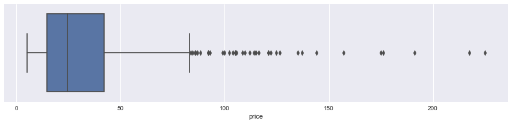

```python
plt.figure(figsize=(15,3))
sns.boxplot(price_serie)
plt.show()
```

Parmis cet ensemble d'outliers, on peut accentuer la vérification des prix sur les produits en stock qui devraient se vendre mais qui n'affichent aucune vente :

```python
outliers_q[(outliers_q["stock_status"] == "instock") & (outliers_q["total_sales"] == 0)]
```

|  | product_id | sku | post_title | stock_status | onsale_web | stock_quantity | price | total_sales | revenue |
| --- | --- | --- | --- | --- | --- | --- | --- | --- | --- |
| 66 | 4115 | 15382 | Zind-Humbrecht Riesling Grand Cru Rangen De Th... | instock | 1 | 11 | 100.00 | 0.00 | 0.00 |
| 68 | 4132 | 11668 | Zind-Humbrecht Pinot Gris Grand Cru Rangen De ... | instock | 1 | 5 | 88.40 | 0.00 | 0.00 |
| 230 | 4406 | 7819 | Cognac Frapin Château de Fontpinot 1989 20 Ans... | instock | 1 | 3 | 157.00 | 0.00 | 0.00 |
| 240 | 4582 | 12857 | Château de Meursault Puligny-Montrachet 1er Cr... | instock | 1 | 7 | 109.60 | 0.00 | 0.00 |
| 410 | 4903 | 14805 | Domaine Des Croix Corton Grand Cru Les Grèves ... | instock | 1 | 20 | 102.30 | 0.00 | 0.00 |
| 460 | 5001 | 14581 | David Duband Charmes-Chambertin Grand Cru 2014 | instock | 1 | 20 | 217.50 | 0.00 | 0.00 |
| 465 | 5007 | 12791 | Domaine des Comtes Lafon Volnay 1er Cru Santen... | instock | 1 | 17 | 105.00 | 0.00 | 0.00 |
| 466 | 5008 | 11602 | Domaine des Comtes Lafon Volnay 1er Cru Santen... | instock | 1 | 10 | 105.00 | 0.00 | 0.00 |
| 476 | 5026 | 13913 | Champagne Agrapart &amp; Fils Minéral Extra Br... | instock | 1 | 2 | 86.80 | 0.00 | 0.00 |
| 551 | 5580 | 13982 | Lucien Boillot Puligny-Montrachet 1er Cru Les ... | instock | 1 | 18 | 83.70 | 0.00 | 0.00 |
| 556 | 5612 | 14915 | Domaine Weinbach Gewurztraminer Grand Cru Furs... | instock | 1 | 12 | 124.80 | 0.00 | 0.00 |
| 598 | 5767 | 15185 | Camille Giroud Clos de Vougeot 2016 | instock | 1 | 12 | 175.00 | 0.00 | 0.00 |
| 650 | 5916 | 14774 | Wemyss Malts Single Cask Scotch Whisky Chocola... | instock | 1 | 3 | 93.00 | 0.00 | 0.00 |
| 651 | 5917 | 14775 | Wemyss Malts Single Cask Scotch Whisky Choc 'n... | instock | 1 | 4 | 122.00 | 0.00 | 0.00 |
| 652 | 5918 | 14773 | Wemyss Malts Single Cask Scotch Whisky Chai Ca... | instock | 1 | 8 | 114.00 | 0.00 | 0.00 |
| 702 | 6201 | 14596 | David Duband Chambolle-Musigny 1er Cru Les Sen... | instock | 1 | 7 | 105.60 | 0.00 | 0.00 |
| 703 | 6202 | 15126 | Domaine Clerget Echezeaux Grand Cru En Orveaux... | instock | 1 | 14 | 116.40 | 0.00 | 0.00 |
| 709 | 6213 | 15072 | Domaine des Comtes Lafon Volnay 1er Cru Santen... | instock | 1 | 7 | 121.00 | 0.00 | 0.00 |
| 710 | 6214 | 11601 | Domaine des Comtes Lafon Volnay 1er Cru Champa... | instock | 1 | 7 | 99.00 | 0.00 | 0.00 |
| 711 | 6215 | 12790 | Domaine des Comtes Lafon Volnay 1er Cru Champa... | instock | 1 | 4 | 115.00 | 0.00 | 0.00 |
| 712 | 6216 | 15070 | Domaine des Comtes Lafon Volnay 1er Cru Champa... | instock | 1 | 6 | 121.00 | 0.00 | 0.00 |

#### Nouveau dataset

```python
df_main = df_main[df_main['price'].between(lower_range_q, upper_range_q)]
```

**Mesures statistiques :**

```python
new_price_mean = df_main['price'].mean()
new_price_median = df_main['price'].median()

print(f"""
Nouvelle Moyenne : {new_price_mean}
Ancienne Moyenne : {price_mean}

Nouvelle Médiane : {new_price_median}
Ancienne Médiane : {price_median}
""")
```

```
Nouvelle Moyenne : 28.256472081218295
Ancienne Moyenne : 32.41563636363637

Nouvelle Médiane : 23.4
Ancienne Médiane : 24.4
```

```python
df_main.describe()
```

|  | product_id | onsale_web | stock_quantity | price | total_sales | revenue |
| --- | --- | --- | --- | --- | --- | --- |
| count | 788.00 | 788.00 | 788.00 | 788.00 | 681.00 | 681.00 |
| mean | 5,158.56 | 0.87 | 27.40 | 28.26 | 4.14 | 93.39 |
| std | 908.59 | 0.34 | 46.75 | 17.52 | 8.68 | 294.83 |
| min | 3,847.00 | 0.00 | 0.00 | 5.20 | 0.00 | 0.00 |
| 25% | 4,303.75 | 1.00 | 1.00 | 14.28 | 0.00 | 0.00 |
| 50% | 4,896.00 | 1.00 | 12.00 | 23.40 | 1.00 | 16.60 |
| 75% | 5,801.25 | 1.00 | 35.00 | 39.00 | 5.00 | 91.00 |
| max | 7,338.00 | 1.00 | 578.00 | 83.00 | 96.00 | 4,704.00 |

Nous abtenons une moyenne corrigée, tandis que la médiane ne diffère par beaucoup.

#### Visualisation

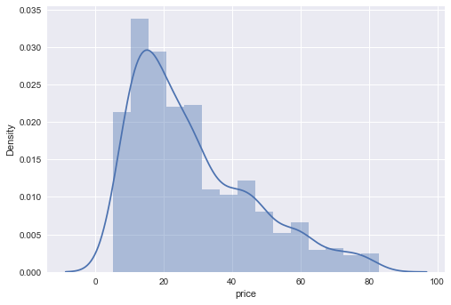

```python
sns.distplot(df_main.price)
```

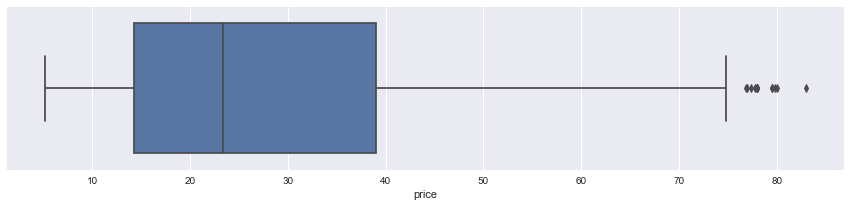

```python
plt.figure(figsize=(15,3))
sns.boxplot(df_main['price'])
plt.show()
```

## Conclusion

**Mise en relation des bases de données :**

La mise en relation des tables de l'EPR et du Web, permet de faire d'avoir une visibilité sur le chiffre d'affaire et la gestion des stocks. Celle-ci a mis en évidence des axes d'améliorations pour les ventes avec des recommandations marketing.

**Valeurs de prix :**

Une valeur atypique est une valeur qui "sort du lot", mais pas forcément fausse.  
On observe plusieurs valeurs extrêmes mais dans le contexte d'une boutique en ligne de vins prestigieux, ces valeurs sont cohérentes.

**Recommandations :**

Pour des modèles de corrélation entre les prix et les ventes, il sera interessant de les traiter les outliers séparemment et en catégorisant les différents produits. Il faudrait vérifier auprès des fournisseurs les prix de ces outliers.  
L'utilisation d'un système centralisé pour les données EPR et Web serait un atout.